# Project: Investigating No Show Appointments in Brazil

- Introduction
- Data Wrangling
- Exploratory Data Analysis
- Conclusions

## Introduction

> Over the course of this notebook, we will explore and observe trends among the different possible factors behind this. We will also try to develop an idea of what factors have a high correlation and high chance of being linked to whether or not one will go to their appointment. Finally, we will end by discussing the results of what we find as well as possible subjects of study in the future to get a better idea of what can eventually help us predict whether someone does or doesn't go to their appointment.

```python
# Use this cell to set up import statements for all of the packages that you
#   plan to use.

# Remember to include a 'magic word' so that your visualizations are plotted
#   inline with the notebook. See this page for more:
#   http://ipython.readthedocs.io/en/stable/interactive/magics.html

import pandas as pd
import numpy as np
import matplotlib.pyplot as plt
import seaborn as sns
% matplotlib inline

#REMEMBER NO MEANS THEY SHOWED AND YES MEANS THEY DIDN"T SHOW
# about the encoding of the last column: it says ‘No’ if the patient
# showed up to their appointment, and ‘Yes’ if they did not show up.
```

## Data Wrangling

> Here we focus on learning more about the data and the datatypes found in the dataframe

### General Properties

```python
# Load your data and print out a few lines. Perform operations to inspect data
#   types and look for instances of missing or possibly errant data.

df = pd.read_csv('noshowappointments-kagglev2-may-2016.csv')
df.head()
```

|  | PatientId | AppointmentID | Gender | ScheduledDay | AppointmentDay | Age | Neighbourhood | Scholarship | Hipertension | Diabetes | Alcoholism | Handcap | SMS_received | No-show |
| --- | --- | --- | --- | --- | --- | --- | --- | --- | --- | --- | --- | --- | --- | --- |
| 0 | 2.987250e+13 | 5642903 | F | 2016-04-29T18:38:08Z | 2016-04-29T00:00:00Z | 62 | JARDIM DA PENHA | 0 | 1 | 0 | 0 | 0 | 0 | No |
| 1 | 5.589978e+14 | 5642503 | M | 2016-04-29T16:08:27Z | 2016-04-29T00:00:00Z | 56 | JARDIM DA PENHA | 0 | 0 | 0 | 0 | 0 | 0 | No |
| 2 | 4.262962e+12 | 5642549 | F | 2016-04-29T16:19:04Z | 2016-04-29T00:00:00Z | 62 | MATA DA PRAIA | 0 | 0 | 0 | 0 | 0 | 0 | No |
| 3 | 8.679512e+11 | 5642828 | F | 2016-04-29T17:29:31Z | 2016-04-29T00:00:00Z | 8 | PONTAL DE CAMBURI | 0 | 0 | 0 | 0 | 0 | 0 | No |
| 4 | 8.841186e+12 | 5642494 | F | 2016-04-29T16:07:23Z | 2016-04-29T00:00:00Z | 56 | JARDIM DA PENHA | 0 | 1 | 1 | 0 | 0 | 0 | No |

```python
df.shape
```

```
(110527, 14)
```

```python
df.info()
#wow every single cell has complete relevant information? yup, looks that way
# it looks like Scholarship, Hipertension, Diabetes, Alcoholism, Handcap, SMS_received
# are all 1,0 values for true, false
```

```
<class 'pandas.core.frame.DataFrame'>
RangeIndex: 110527 entries, 0 to 110526
Data columns (total 14 columns):
PatientId         110527 non-null float64
AppointmentID     110527 non-null int64
Gender            110527 non-null object
ScheduledDay      110527 non-null object
AppointmentDay    110527 non-null object
Age               110527 non-null int64
Neighbourhood     110527 non-null object
Scholarship       110527 non-null int64
Hipertension      110527 non-null int64
Diabetes          110527 non-null int64
Alcoholism        110527 non-null int64
Handcap           110527 non-null int64
SMS_received      110527 non-null int64
No-show           110527 non-null object
dtypes: float64(1), int64(8), object(5)
memory usage: 11.8+ MB
```

```python
df.describe()
```

|  | PatientId | AppointmentID | Age | Scholarship | Hipertension | Diabetes | Alcoholism | Handcap | SMS_received |
| --- | --- | --- | --- | --- | --- | --- | --- | --- | --- |
| count | 1.105270e+05 | 1.105270e+05 | 110527.000000 | 110527.000000 | 110527.000000 | 110527.000000 | 110527.000000 | 110527.000000 | 110527.000000 |
| mean | 1.474963e+14 | 5.675305e+06 | 37.088874 | 0.098266 | 0.197246 | 0.071865 | 0.030400 | 0.022248 | 0.321026 |
| std | 2.560949e+14 | 7.129575e+04 | 23.110205 | 0.297675 | 0.397921 | 0.258265 | 0.171686 | 0.161543 | 0.466873 |
| min | 3.921784e+04 | 5.030230e+06 | -1.000000 | 0.000000 | 0.000000 | 0.000000 | 0.000000 | 0.000000 | 0.000000 |
| 25% | 4.172614e+12 | 5.640286e+06 | 18.000000 | 0.000000 | 0.000000 | 0.000000 | 0.000000 | 0.000000 | 0.000000 |
| 50% | 3.173184e+13 | 5.680573e+06 | 37.000000 | 0.000000 | 0.000000 | 0.000000 | 0.000000 | 0.000000 | 0.000000 |
| 75% | 9.439172e+13 | 5.725524e+06 | 55.000000 | 0.000000 | 0.000000 | 0.000000 | 0.000000 | 0.000000 | 1.000000 |
| max | 9.999816e+14 | 5.790484e+06 | 115.000000 | 1.000000 | 1.000000 | 1.000000 | 1.000000 | 4.000000 | 1.000000 |

### Data Cleaning

> A really neat thing is that there are no null values, which is awesome for a dataframe!

> However, the No-Show column is a little confusing in what it means, so we're gonna create a new column called 'Showed' with 1 being they were present for their appointment and 0 being a No-Show

> Of course it's important to remember that Yes means they missed and No means they were present in the 'No-Show' column, so we'll have Yes map to 0 and No map to 1

> After that we can drop the 'No-Show' column and look at our new data

```python
#Let's make an extra col for No-show with Showed and values of 1 for Yes and 0 for No to make it easier
# to work with

# WRONG REMEMBER NO MEANS THEY SHOWED AND YES MEANS THEY DIDN"T SHOW
# "about the encoding of the last column: it says ‘No’ if the patient
# showed up to their appointment, and ‘Yes’ if they did not show up."

#Then we can drop the No-show col since Showed answers that for us

df['Showed'] = df['No-show'].map(dict(Yes=0, No=1))
df.drop(['No-show'], axis=1, inplace=True)
df.head()
```

|  | PatientId | AppointmentID | Gender | ScheduledDay | AppointmentDay | Age | Neighbourhood | Scholarship | Hipertension | Diabetes | Alcoholism | Handcap | SMS_received | Showed |
| --- | --- | --- | --- | --- | --- | --- | --- | --- | --- | --- | --- | --- | --- | --- |
| 0 | 2.987250e+13 | 5642903 | F | 2016-04-29T18:38:08Z | 2016-04-29T00:00:00Z | 62 | JARDIM DA PENHA | 0 | 1 | 0 | 0 | 0 | 0 | 1 |
| 1 | 5.589978e+14 | 5642503 | M | 2016-04-29T16:08:27Z | 2016-04-29T00:00:00Z | 56 | JARDIM DA PENHA | 0 | 0 | 0 | 0 | 0 | 0 | 1 |
| 2 | 4.262962e+12 | 5642549 | F | 2016-04-29T16:19:04Z | 2016-04-29T00:00:00Z | 62 | MATA DA PRAIA | 0 | 0 | 0 | 0 | 0 | 0 | 1 |
| 3 | 8.679512e+11 | 5642828 | F | 2016-04-29T17:29:31Z | 2016-04-29T00:00:00Z | 8 | PONTAL DE CAMBURI | 0 | 0 | 0 | 0 | 0 | 0 | 1 |
| 4 | 8.841186e+12 | 5642494 | F | 2016-04-29T16:07:23Z | 2016-04-29T00:00:00Z | 56 | JARDIM DA PENHA | 0 | 1 | 1 | 0 | 0 | 0 | 1 |

```python
# Now let's get a sense for the info and describe() of our df as is
print(df.info())
df.describe()
```

```
<class 'pandas.core.frame.DataFrame'>
RangeIndex: 110527 entries, 0 to 110526
Data columns (total 14 columns):
PatientId         110527 non-null float64
AppointmentID     110527 non-null int64
Gender            110527 non-null object
ScheduledDay      110527 non-null object
AppointmentDay    110527 non-null object
Age               110527 non-null int64
Neighbourhood     110527 non-null object
Scholarship       110527 non-null int64
Hipertension      110527 non-null int64
Diabetes          110527 non-null int64
Alcoholism        110527 non-null int64
Handcap           110527 non-null int64
SMS_received      110527 non-null int64
Showed            110527 non-null int64
dtypes: float64(1), int64(9), object(4)
memory usage: 11.8+ MB
None
```

|  | PatientId | AppointmentID | Age | Scholarship | Hipertension | Diabetes | Alcoholism | Handcap | SMS_received | Showed |
| --- | --- | --- | --- | --- | --- | --- | --- | --- | --- | --- |
| count | 1.105270e+05 | 1.105270e+05 | 110527.000000 | 110527.000000 | 110527.000000 | 110527.000000 | 110527.000000 | 110527.000000 | 110527.000000 | 110527.000000 |
| mean | 1.474963e+14 | 5.675305e+06 | 37.088874 | 0.098266 | 0.197246 | 0.071865 | 0.030400 | 0.022248 | 0.321026 | 0.798067 |
| std | 2.560949e+14 | 7.129575e+04 | 23.110205 | 0.297675 | 0.397921 | 0.258265 | 0.171686 | 0.161543 | 0.466873 | 0.401444 |
| min | 3.921784e+04 | 5.030230e+06 | -1.000000 | 0.000000 | 0.000000 | 0.000000 | 0.000000 | 0.000000 | 0.000000 | 0.000000 |
| 25% | 4.172614e+12 | 5.640286e+06 | 18.000000 | 0.000000 | 0.000000 | 0.000000 | 0.000000 | 0.000000 | 0.000000 | 1.000000 |
| 50% | 3.173184e+13 | 5.680573e+06 | 37.000000 | 0.000000 | 0.000000 | 0.000000 | 0.000000 | 0.000000 | 0.000000 | 1.000000 |
| 75% | 9.439172e+13 | 5.725524e+06 | 55.000000 | 0.000000 | 0.000000 | 0.000000 | 0.000000 | 0.000000 | 1.000000 | 1.000000 |
| max | 9.999816e+14 | 5.790484e+06 | 115.000000 | 1.000000 | 1.000000 | 1.000000 | 1.000000 | 4.000000 | 1.000000 | 1.000000 |

```python
# Great! Now we have an easy way of seeing how many people showed.
# Since most of the other columns have 0-1 values for whether they are False-True,
# we also get a snapshot at the perentage of people who are positive for that column

# Below we have the percentage of people who went to appointments, along with
# how many went (1) and how many didn't (0)

print(df.Showed.mean())
df.Showed.value_counts()
```

```
0.798067440534892
```

```
1    88208
0    22319
Name: Showed, dtype: int64
```

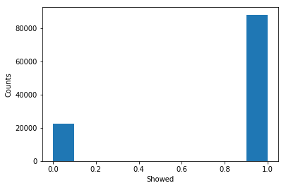

```python
plt.hist(df['Showed']);
plt.ylabel('Counts')
plt.xlabel('Showed')
plt.show()
```

## Exploratory Data Analysis

> Now we can move on to exploring different facets of the data.

> Overall, it seems like the data can be split into columns with True or False values, such as Scholarship or Hipertension, or columns with multiple categorical values, such as the Gender of the patient, or what Neighbourhood a patient is from

### Research Question 1: How do Don't Have/Have Column Values affect a patient's likelihood of going to the doctor?

```python
# Let's make two new dfs with whether or not the patients showed to have on hand
dfShowed = df[df['Showed']== 1]
dfNoShow = df[df['Showed'] == 0]
```

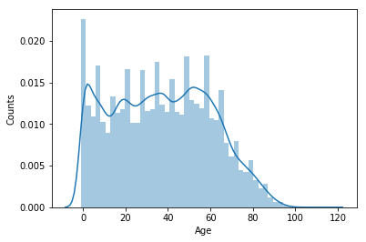

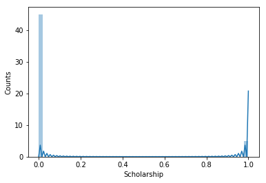

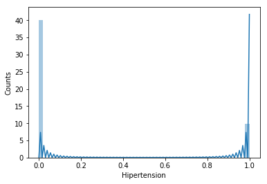

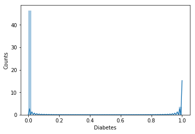

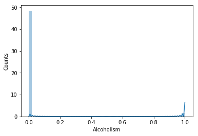

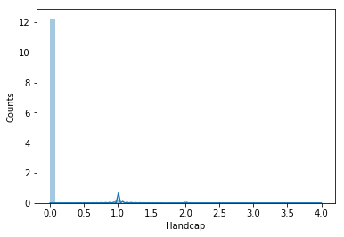

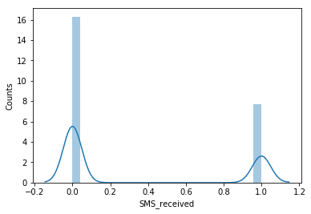

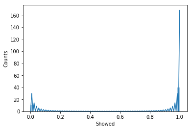

```python
# First, let's make a quick set of histograms to see the distributions of column values across
# all patients, those that showed, and those that didn't


colVals = ['Age', 'Scholarship', 'Hipertension',
           'Diabetes', 'Alcoholism', 'Handcap', 'SMS_received', 'Showed']

for col in colVals:
    sns.distplot(df[col]);
    plt.ylabel('Counts')
    plt.show()
```

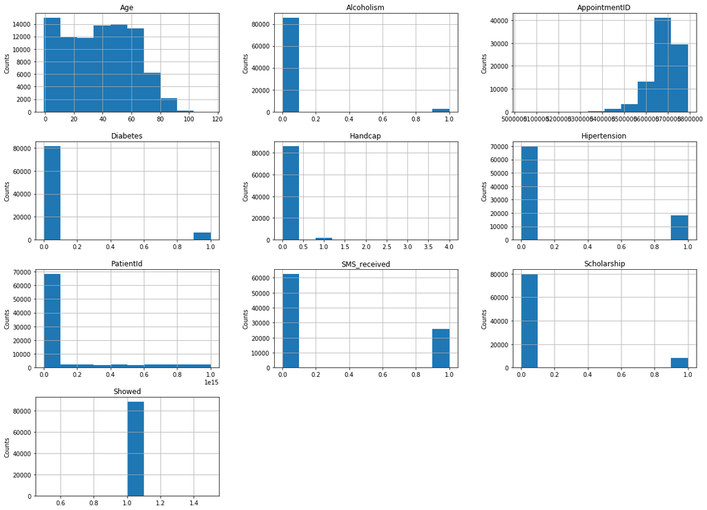

```python
axarr = dfShowed.hist(figsize = (20,15));
for ax in axarr.flatten():
    ax.set_ylabel("Counts")
```

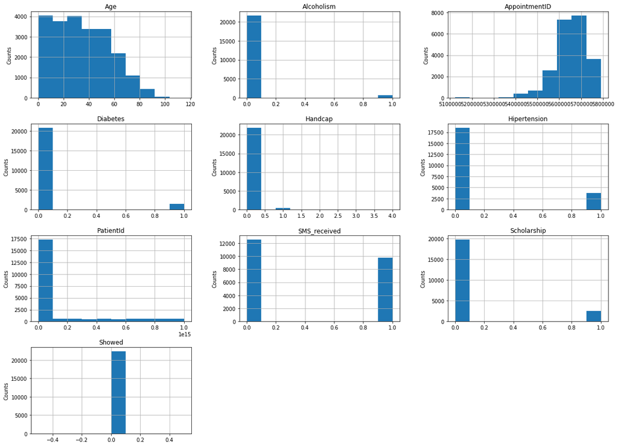

```python
axarr = dfNoShow.hist(figsize = (20,15));
for ax in axarr.flatten():
    ax.set_ylabel("Counts")
```

At first glance it seems there is not much difference between the histograms of those who showed and those who didn't, so we'll need to examine the data on a closer level for each of the relevant columns

The columns that we'll be most interested in are: ['Age', 'Scholarship', 'Hipertension', 'Diabetes', 'Alcoholism', 'Handcap', 'SMS_received']

Age is a little more involved since there is a large range of values present, so let's focus on something with a smaller range first: Handcap

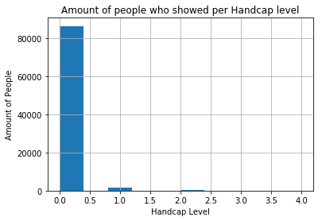

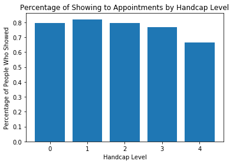

```
Percentage Showing at Appointments with Handcap 0 : 0.7976469719077258
Percentage Showing at Appointments with Handcap 1 : 0.8207639569049952
Percentage Showing at Appointments with Handcap 2 : 0.7978142076502732
Percentage Showing at Appointments with Handcap 3 : 0.7692307692307693
Percentage Showing at Appointments with Handcap 4 : 0.6666666666666666
```

```python
#df[df.Handcap == 0].Showed.hist();
#plt.title('')
#plt.show();
#df[df.Handcap >= 1].Showed.hist();
dfShowed.Handcap.hist();
plt.title('Amount of people who showed per Handcap level')
plt.xlabel('Handcap Level')
plt.ylabel('Amount of People')
plt.show()

plt.bar(df.groupby('Handcap').Handcap.unique(), df.groupby('Handcap').Showed.mean());
plt.title('Percentage of Showing to Appointments by Handcap Level')
plt.ylabel('Percentage of People Who Showed')
plt.xlabel('Handcap Level')
plt.show()

for i in range(5):
    print('Percentage Showing at Appointments with Handcap ' + str(i) + ' : ' +
         str(df[df.Handcap == i].Showed.mean()))
```

So we can see how likely one is to go with certain Handcaps

let's look at all the True-or-False/0-or-1 columns to see how they match up

```python
numericCols = ['Scholarship', 'Hipertension', 'Diabetes', 'Alcoholism', 'SMS_received']
showedColMeans = []
noShowColMeans = []
overallColMeans = []
for col in numericCols:
    #showedColMeans.append(dfShowed[col].mean())
    print(col + ' means: ')
    print('overall mean of ' + col + ' column:')
    print(df[col].mean())
    print('mean of ' + col + ' column of those who showed:')
    print(dfShowed[col].mean())
    print('mean of ' + col + ' column of those who were no-shows:')
    print(dfNoShow[col].mean())
    print('')
```

```
Scholarship means:
overall mean of Scholarship column:
0.09826558216544373
mean of Scholarship column of those who showed:
0.09390304734264465
mean of Scholarship column of those who were no-shows:
0.11550696715802679

Hipertension means:
overall mean of Hipertension column:
0.1972459218109602
mean of Hipertension column of those who showed:
0.20439189189189189
mean of Hipertension column of those who were no-shows:
0.16900398763385457

Diabetes means:
overall mean of Diabetes column:
0.07186479321794674
mean of Diabetes column of those who showed:
0.0738368401959006
mean of Diabetes column of those who were no-shows:
0.06407097092163627

Alcoholism means:
overall mean of Alcoholism column:
0.030399811810688793
mean of Alcoholism column of those who showed:
0.030416742245601307
mean of Alcoholism column of those who were no-shows:
0.030332900219543886

SMS_received means:
overall mean of SMS_received column:
0.32102563174608917
mean of SMS_received column of those who showed:
0.2913341193542536
mean of SMS_received column of those who were no-shows:
0.43837089475334917
```

So for the most part, it seems like the difference between the percentage of people with a quality and the percentage of people who showed with that quality is very slim

Okay let's check out these features but by measuring percentage of those who show with quality value rather than percentage of those with a quality value from those that showed

```python
numericCols = ['Scholarship', 'Hipertension', 'Diabetes', 'Alcoholism', 'SMS_received']
showedWithColMeans = []
showedWithoutColMeans = []
diffBetweenShowAndNoShowMeans = []
for col in numericCols:
    #showedColMeans.append(dfShowed[col].mean())
    colDf = df[df[col] == 1]
    print(col + ' means: ')
    print('percentage of those who showed with ' + col + ':')
    print(colDf.Showed.mean())
    showedWithColMeans.append(colDf.Showed.mean())
    colDf2 = df[df[col] == 0]
    print('percentage of those who showed without ' + col +':')
    print(colDf2.Showed.mean())
    showedWithoutColMeans.append(colDf2.Showed.mean())

    print('people with ' + col + ' were: ')

    #print(str(colDf.Showed.mean() - colDf2.Showed.mean()))
    print(str(colDf.Showed.mean() - colDf2.Showed.mean()) + ' percent more likely to show than those without ' + col)
    diffBetweenShowAndNoShowMeans.append(colDf.Showed.mean() - colDf2.Showed.mean())
    print('')
```

```
Scholarship means:
percentage of those who showed with Scholarship:
0.7626369579228433
percentage of those who showed without Scholarship:
0.8019284409929164
people with Scholarship were:
-0.03929148307007313 percent more likely to show than those without Scholarship

Hipertension means:
percentage of those who showed with Hipertension:
0.8269804137424889
percentage of those who showed without Hipertension:
0.7909631900457589
people with Hipertension were:
0.036017223696729994 percent more likely to show than those without Hipertension

Diabetes means:
percentage of those who showed with Diabetes:
0.8199672667757774
percentage of those who showed without Diabetes:
0.7963717538797473
people with Diabetes were:
0.023595512896030013 percent more likely to show than those without Diabetes

Alcoholism means:
percentage of those who showed with Alcoholism:
0.7985119047619048
percentage of those who showed without Alcoholism:
0.798053505276811
people with Alcoholism were:
0.0004583994850938522 percent more likely to show than those without Alcoholism

SMS_received means:
percentage of those who showed with SMS_received:
0.7242545516036301
percentage of those who showed without SMS_received:
0.8329668865347458
people with SMS_received were:
-0.10871233493111576 percent more likely to show than those without SMS_received
```

So with the above we start getting a better idea of what conditions can make it more or less likely for a patient to attend their appointment with their doctor

It may be helpful to make a few plots to get a better visual feel for how having or not having a quality changes the likelihood of going to the doctor

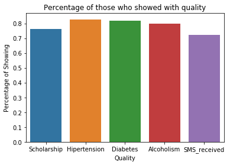

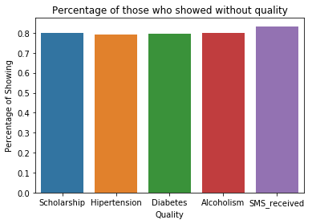

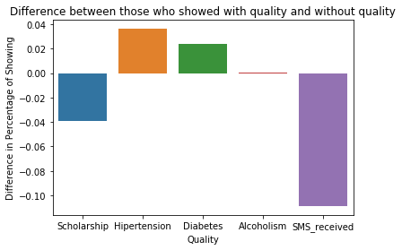

```python
# Let's rewrite our colNames and the lists we want to plot to avoid going back and forth

numericCols = ['Scholarship', 'Hipertension', 'Diabetes', 'Alcoholism', 'SMS_received']
#showedWithColMeans = []
#showedWithoutColMeans = []
#diffBetweenShowAndNoShowMeans = []

sns.barplot(numericCols, showedWithColMeans);
plt.title('Percentage of those who showed with quality')
plt.ylabel('Percentage of Showing')
plt.xlabel('Quality')
plt.show()

sns.barplot(numericCols, showedWithoutColMeans);
plt.title('Percentage of those who showed without quality')
plt.ylabel('Percentage of Showing')
plt.xlabel('Quality')
plt.show()

sns.barplot(numericCols, diffBetweenShowAndNoShowMeans);
plt.title('Difference between those who showed with quality and without quality')
plt.ylabel('Difference in Percentage of Showing')
plt.xlabel('Quality')
plt.show()
```

With the above plots we have a much better idea of what quality has a higher chance of having the patient show for their appointment, and we even see that two qualities reduce the likelihood of a patient going for their appointment.

Further research would be needed to examine why this trend occurs the way it does, but for now we have discovered a preliminary trend on what qualities make someone likely to go to the doctor or now

Now let's examine all the qualities we have just seen but on a more individual level and within the same cell

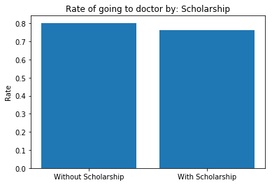

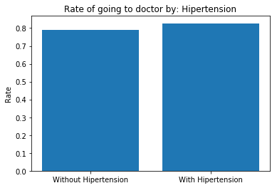

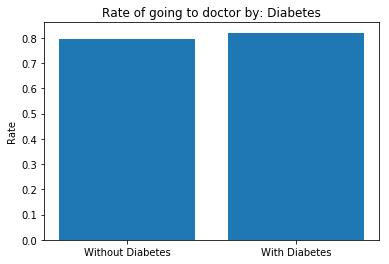

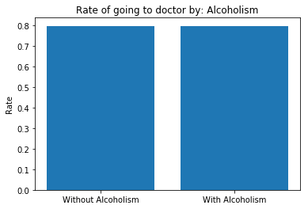

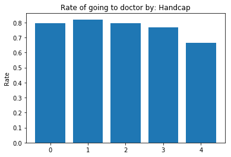

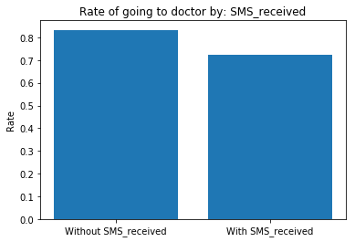

```python
numericCols = ['Scholarship', 'Hipertension', 'Diabetes', 'Alcoholism', 'Handcap', 'SMS_received']
for col in numericCols:
    x = df.groupby(col)[col].mean()
    y = (df.groupby(col).Showed.mean())
    if col != 'Handcap':
        x = ['Without '+ col, 'With '+col]
    plt.bar(x, y);
    plt.title('Rate of going to doctor by: '+ col)
    plt.ylabel('Rate')
    plt.show()
```

And finally, we can get a plot to see how Age affects people going to the doctor for their appointments

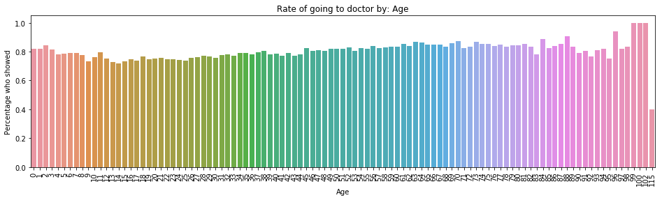

```python
col = 'Age'
x = df.groupby(col)[col].mean()
y = (df.groupby(col).Showed.mean())
#plt.bar(x, y);
#plt.title('rate of going to doctor by: '+ col)
#plt.show()
x = x[1:]
y = y[1:]
#Let's get rid of a -1 typo that appears in the first row
plt.figure(figsize=(16,4))
plt.xticks(rotation=90)
sns.barplot(x,y);
plt.title('Rate of going to doctor by: '+ col)
plt.ylabel('Percentage who showed')
plt.show()
```

In the above graph, we managed to get a good idea of the likelihood of showing up at the appointment by age. It seems to be pretty uniform all the way up to much older ages. This makes sense - you don't get to 100 without having concern for your health. Except maybe for those individuals at 115. They seem very confident in their health.

With this, we have a potential list of factors that determine one's likeliness of going to their appointment:

##### 'Scholarship', 'Hipertension', 'Diabetes', 'Handcap', 'SMS_received'.

Hipertension and Diabetes being the greatest marker towards going, and SMS_received being the greatest marker towards not going

### Research Question 2: Would other factors such as Neighbourhood or Gender have a greater effect?

```python
# Continue to explore the data to address your additional research
#   questions. Add more headers as needed if you have more questions to
#   investigate.


#So the numerical factors that have like a 0, 1 value don't change much between
#Showed and NoShow, so let's anaylyze the spread of the non-numerical data then
```

```python
#Let's bring the head back in to see all cols again
df.head()
```

|  | PatientId | AppointmentID | Gender | ScheduledDay | AppointmentDay | Age | Neighbourhood | Scholarship | Hipertension | Diabetes | Alcoholism | Handcap | SMS_received | Showed |
| --- | --- | --- | --- | --- | --- | --- | --- | --- | --- | --- | --- | --- | --- | --- |
| 0 | 2.987250e+13 | 5642903 | F | 2016-04-29T18:38:08Z | 2016-04-29T00:00:00Z | 62 | JARDIM DA PENHA | 0 | 1 | 0 | 0 | 0 | 0 | 1 |
| 1 | 5.589978e+14 | 5642503 | M | 2016-04-29T16:08:27Z | 2016-04-29T00:00:00Z | 56 | JARDIM DA PENHA | 0 | 0 | 0 | 0 | 0 | 0 | 1 |
| 2 | 4.262962e+12 | 5642549 | F | 2016-04-29T16:19:04Z | 2016-04-29T00:00:00Z | 62 | MATA DA PRAIA | 0 | 0 | 0 | 0 | 0 | 0 | 1 |
| 3 | 8.679512e+11 | 5642828 | F | 2016-04-29T17:29:31Z | 2016-04-29T00:00:00Z | 8 | PONTAL DE CAMBURI | 0 | 0 | 0 | 0 | 0 | 0 | 1 |
| 4 | 8.841186e+12 | 5642494 | F | 2016-04-29T16:07:23Z | 2016-04-29T00:00:00Z | 56 | JARDIM DA PENHA | 0 | 1 | 1 | 0 | 0 | 0 | 1 |

```python
#Let's quickly get an idea of the values behind both categories

print(df.Neighbourhood.value_counts().head())
print(df.Gender.value_counts())
print(dfShowed.Gender.value_counts())

print(dfShowed.Gender.value_counts()/df.Gender.value_counts())
```

```
JARDIM CAMBURI     7717
MARIA ORTIZ        5805
RESISTÊNCIA        4431
JARDIM DA PENHA    3877
ITARARÉ            3514
Name: Neighbourhood, dtype: int64
F    71840
M    38687
Name: Gender, dtype: int64
F    57246
M    30962
Name: Gender, dtype: int64
F    0.796854
M    0.800321
Name: Gender, dtype: float64
```

So very quickly we can see what the gender make up is, and what percentage Female and Male patients showed to their appointments, again it comes up as around 80%

Next let's try to plot and gather information about gender

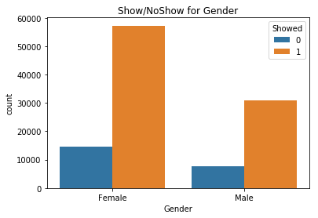

```python
ax = sns.countplot(x=df.Gender, hue=df.Showed, data=df)
ax.set_title("Show/NoShow for Gender")
x_ticks_labels=['Female', 'Male']
ax.set_xticklabels(x_ticks_labels)
plt.show()
```

while a lot more women make appointments than men, approximately the same percentage end up missing overall, as shown below

```
Difference in percentage of showing to appointment between Male and Female: genders
0.0034664008380203004
```

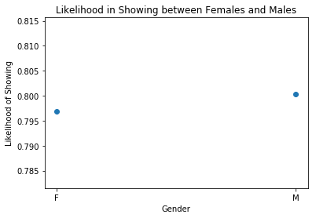

```python
props = dfShowed.groupby('Gender').size()/df.groupby('Gender').size()
print('Difference in percentage of showing to appointment between Male and Female: genders')
print(max(props) - min(props))

plt.scatter(df.Gender.unique(), props);
plt.title('Likelihood in Showing between Females and Males');
#The graph below shows very little difference in the likelihood of going to
#appointment between male and female - only about a 0.3% change oh well
plt.ylabel('Likelihood of Showing')
plt.xlabel('Gender')
plt.show()
```

There is less than a 1% difference in the probability of a patient going if one is Male or Female, so this is highly unlikely to be a factor determining whether one goes to their appointment, although it is on it's own still a large factor of whether a patient *makes* the appointment in the first place, according to this dataset

Let's try analyzing data by Neighbourhood next

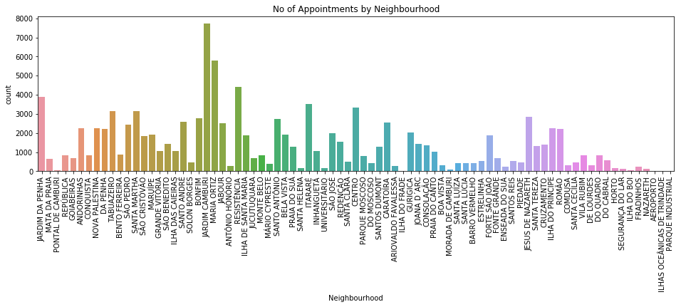

```python
plt.figure(figsize=(16,4))
plt.xticks(rotation=90)
ax = sns.countplot(x=df.Neighbourhood)
ax.set_title("No of Appointments by Neighbourhood")
plt.show()
```

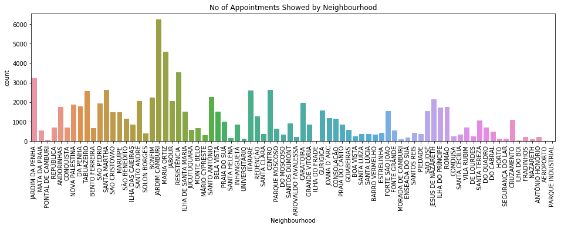

```python
plt.figure(figsize=(16,4))
plt.xticks(rotation=90)
ax = sns.countplot(x=dfShowed.Neighbourhood)
ax.set_title("No of Appointments Showed by Neighbourhood")
plt.show()
```

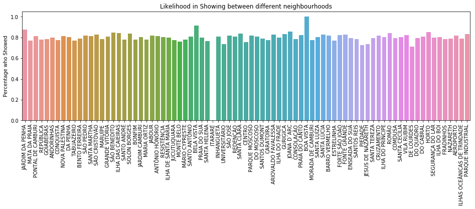

```python
# Now let's try it out on neighborhoods

props = dfShowed.groupby('Neighbourhood').size()/df.groupby('Neighbourhood').size()
#props2 = props[np.logical_not(np.isnan(x))]

plt.figure(figsize=(16,4))
#sns.distplot(props2);
#plt.show()

sns.barplot(df['Neighbourhood'].unique(), props);
plt.xticks(rotation=90)
plt.title('Likelihood in Showing between different neighbourhoods');
plt.ylabel('Percentage who Showed')
plt.show()
```

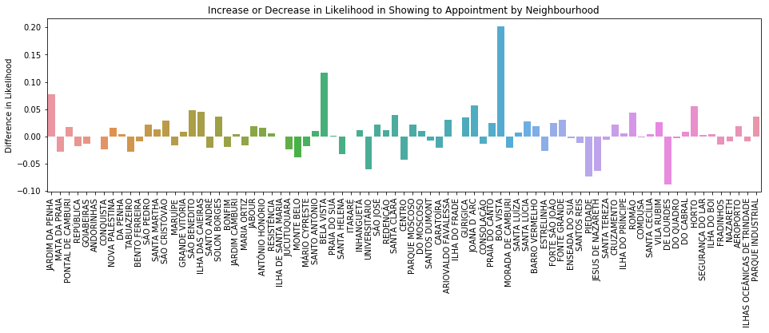

```python
# Now let's compare neighborhoods to the average showing rate

props = (dfShowed.groupby('Neighbourhood').size()/df.groupby('Neighbourhood').size()) - df.Showed.mean()
#props2 = props[np.logical_not(np.isnan(props))]

plt.figure(figsize=(16,4))
#sns.distplot(props2);
#plt.show()

sns.barplot(df['Neighbourhood'].unique(), props);
plt.xticks(rotation=90)
plt.title('Increase or Decrease in Likelihood in Showing to Appointment by Neighbourhood');
plt.ylabel('Difference in Likelihood')
plt.show()
```

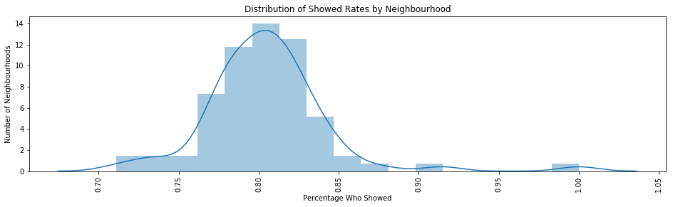

```python
plt.figure(figsize=(16,4))
plt.xticks(rotation=90)
props = (dfShowed.groupby('Neighbourhood').size()/df.groupby('Neighbourhood').size())
props2 = props[np.logical_not(np.isnan(props))]
ax = sns.distplot(props2)
ax.set_title("Distribution of Showed Rates by Neighbourhood")
plt.xlabel('Percentage Who Showed')
plt.ylabel('Number of Neighbourhoods')
plt.show()
```

Overall it seems like most neighborhoods are within 75-85% chance of going to their appointment - about 52 of the 81 neighborhoods more or less. The upper 3 neighborhoods have above a 85% chance of going though

Finally, we can do a quick scan through appointment day and see if anything stands out there

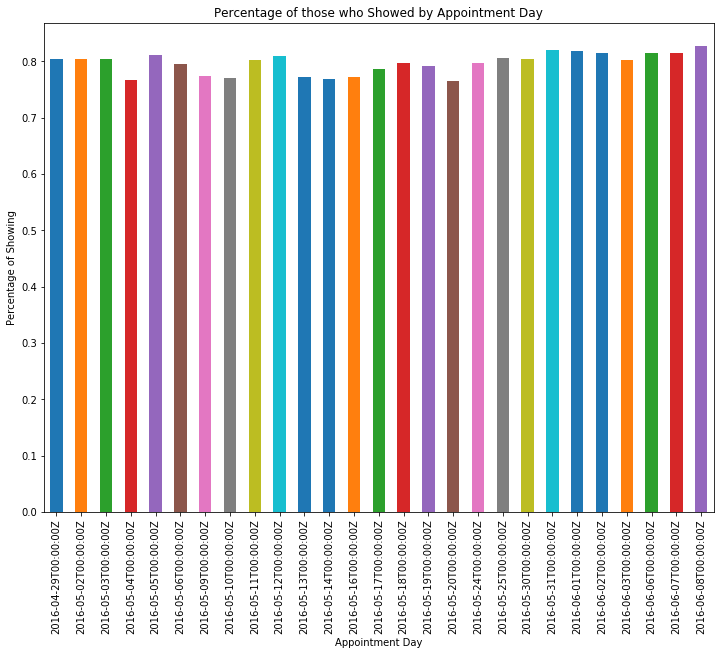

```python
#(pd.value_counts(dfShowed.AppointmentDay)/(pd.value_counts(dfShowed.AppointmentDay) + pd.value_counts(dfNoShow.AppointmentDay))).plot.bar(figsize=(12, 9));
(pd.value_counts(dfShowed.AppointmentDay)/pd.value_counts(df.AppointmentDay)).plot.bar(figsize=(12, 9));
plt.title('Percentage of those who Showed by Appointment Day');
plt.ylabel('Percentage of Showing')
plt.xlabel('Appointment Day')
plt.show()
```

Overall, nothing really seems to stand out amongst the dates, they all have an overall 75%-85% chance of arriving for their appointment.

## Conclusions

Overall, from the data that we have had the chance to work with, we notice a few things that stand out:

> In regards to Question 1, whether the Don't Have/Have columns make an impact:
> 1. Having Hipertension, Diabetes, and Handcap 1 correlated with increase likelihood of showing over those without those conditions. This makes sense, since these tend to be chronic issues that need to be consistently cared for.
> 2. Having a Scholarship or receiving and SMS correlated with a lower likelihood of showing to appointments. This was a bit more surprising as one would think those with a Scholarship or those who receive a reminder would be more likely to show. A few possible reasons could be conditions given by the scholarship fund or the fact that sms reminders are more likely to happen when there is a longer waiting time between making the appointment and going to the appointment. Both of these could be further subjects of study to get a more complete picture of the factors involved in going or not going.
> 3. Having Alcoholism, however, seemed to have almost no correlation to whether or not one went to their appointment, as it was barely a 0.05% increase in likelihood of going, so it doesn't seem like something that should be studied in detail.
> 4. The highest correlation with going to the appointment comes from having Hipertension, which has a 4% increase in likelihood of going. The factor with the largest negative correlation (and the largest overall correlation) came from whether they received an SMS or not at -10%, making this a prime factor to study and learn more about.

In regards to Question 2, whether Gender or Neighbourhood make an impact:

> 1. The gender of the patient seemed to have almost no correlation to whether or not they went to their appointment, as there was barely a 0.35% difference in their rate of showing.
> 2. However, there was a large difference in the *number* of those who made appointments by Gender, with women making 65% of the patients, almost double that of the men. While gender does not have a strong correlation on whether or not one goes to their appointment in this dataset, this could be a subject of further study on the issue of who seeks out and ends up receiving medical treatment in the country of Brazil.
> 3. In regards to neighbourhoods - while they all are close in range of percentage showing (with approximately 50 of the 81 neighbourhoods in the 75%-85% range), there are a number of neighbourhoods that are distinctly above the average and below the average, inviting further study on whether that is simply a correlation or if there are other external factors within the neighbourhoods that increase or decrease the likelihood of going to one's appointment.
> 4. The percentage of those who showed by appointment day is similarly uniformly distributed, more study could be done on which day of the week is likely to have more people show, if there is anything related to Holiday's that make people more or less likely to go, and to see if an increase or decrease in showing can be linked to an external campaign or event happening in the city, health related or otherwise.

Finally, there are some limitation to keep in mind and areas of further study:

> 1. It is important to keep in mind that this data set is only over the course of 2 months, with not every day being filled.
> 2. We don't as of yet know if this is a representative sample data for all the medical appointments over those two months or if it was curated to those dates that we were given or from a specific medical center. Going further we would want to know this information as it would inform how significant our findings from the data are.
> 3. Another exciting subject of study with the more complete information would be to see waiting times over a larger period and if they are linked with lower likelihoods of going to appointment. Learning more about the reasons someone wanted to make an appointment, as well as what times the appointments were for, would be a beneficial aid in forming a model on what factors cause people to show or not show to their appointments.